# Diagonal Case

## 6.3 The output from the fit

Here is the fitted spline curve to the number of unmarked fish available in each recovery sample.

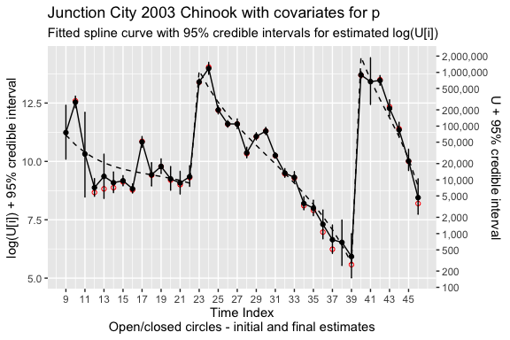

Fitted spline curve with covariate for p

```r
demo3.fit$plots$fit.plot
```

The jump in the spline when hatchery fish are released is evident.

The distribution of the posterior sample for the total number unmarked and total abundance is available as before:

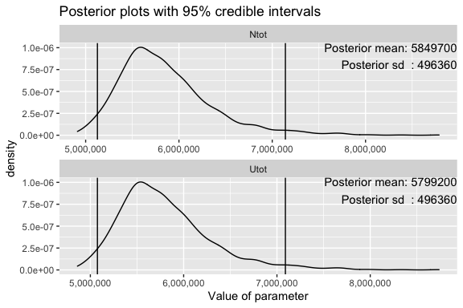

Distribution of posterior samples

```r
demo3.fit$plots$post.UNtot.plot
```

A plot of the $logit(P)$ is

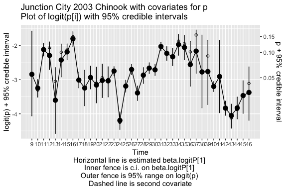

Estimates of logit(p)

```r
demo3.fit$plots$logitP.plot
```

Here is a plot of the estimated $logit(p)$’s vs. the log(flow) and its fitted curve:

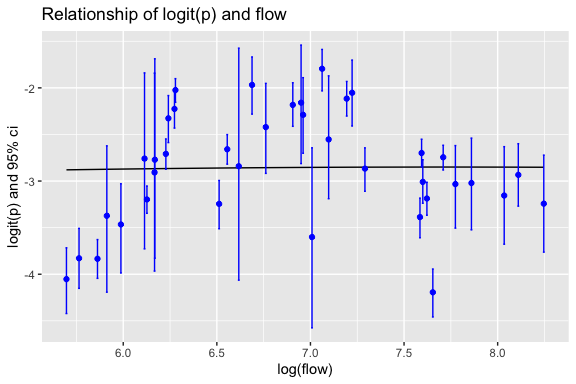

There is virtually no evidence of a relationship with flow because of the very large uncertainties in each of the estimated $logit(p)$.

The estimated coefficients of the quadratic relationship between logit(p) and *log(flow)* are:

```r
round(demo3.fit$summary[demo3.coeff.row.index,],3)
```

```
#>                  mean    sd   2.5%    25%    50%    75%  97.5%  Rhat n.eff
#> beta.logitP[1] -3.294 0.948 -5.170 -3.927 -3.284 -2.663 -1.407 1.003  1500
#> beta.logitP[2]  0.115 0.328 -0.541 -0.101  0.111  0.333  0.743 1.001  1500
#> beta.logitP[3] -0.007 0.031 -0.068 -0.028 -0.007  0.012  0.054 1.001  1500
```

A summary of the posterior for each parameter is also available. In particular, here are the summary statistics on the posterior sample for the total number unmarked and total abundance:

```r
demo3.fit$summary[ row.names(demo3.fit$summary) %in% c("Ntot","Utot"),]
```

```
#>         mean       sd    2.5%     25%     50%     75%   97.5%     Rhat n.eff
#> Ntot 5849700 496356.9 5126187 5519334 5762912 6082048 7141051 1.002868   730
#> Utot 5799235 496356.9 5075722 5468869 5712447 6031583 7090586 1.002868   730
```

The estimated total abundance from $BTSPAS$ is 5,849,700 (SD 496,357 ) fish.

# 7 Using covariates to model the p’s - prior information about beta coefficients

*BTSPAS* also allows you to model the p’s with additional covariates, such a temperature, stream flow, etc. It is not possible to use covariates to model the total number of unmarked fish.

In some cases, you may have additional information about the effect of the covariates that you would like to incorporate into the analysis. For example, a rotary screw trap may have run for many years and plots of the relationship between the *logit(catchability)* vs. *log(flow)* generally shows a relationship that you may not be able to capture in a single year because of lack of contrast (i.e. the flow within a year does not vary enough) or because of smallish sample sizes.

*BTSPAS* allows you to specify prior information on the coefficients of the relationship between *logit(catchability)* and covariates.

We will show an example where four models are fit to the same data

- no relationship between *logit(catchability)* and *log(flow)*;
- linear relationship between *logit(catchability)* and *log(flow)* with the default priors;
- linear relationship between *logit(catchability)* and *log(flow)* with weak priors;
- linear relationship between *logit(catchability)* and *log(flow)* with strong priors (and the prior information conflicts with the fit),

## 7.1 Reading in the data

Here is an example of some (fictitious) raw data that includes the covariate $log(flow)$:

```r
demo5.data.csv <- textConnection(
'time,   n1,     m2,       u2,       logFlow
1   ,      0   ,    0   ,      21   ,   5.415
2   ,     56   ,    8   ,    2266   ,   5.358
3   ,   1009   ,   59   ,   11314   ,   6.737
4   ,   1284   ,   25   ,    5035   ,   7.993
5   ,   1504   ,   13   ,     396   ,   8.693
6   ,      0   ,    0   ,      45   ,   8.861
7   ,      0   ,    0   ,      26   ,   8.587
8   ,   1560   ,   17   ,      12   ,   8.347
9   ,   1643   ,   14   ,      43   ,   8.260
10   ,     0   ,    0   ,      63   ,   8.606
11   ,  1487   ,    7   ,      24   ,   8.671
12   ,     0   ,    0   ,       5   ,   8.737
13   ,     0   ,    0   ,       4   ,   7.862')

demo5.data <- read.csv(demo5.data.csv, header=TRUE, as.is=TRUE, strip.white=TRUE)

print(demo5.data)
```

```
#>    time   n1 m2    u2 logFlow
#> 1     1    0  0    21   5.415
#> 2     2   56  8  2266   5.358
#> 3     3 1009 59 11314   6.737
#> 4     4 1284 25  5035   7.993
#> 5     5 1504 13   396   8.693
#> 6     6    0  0    45   8.861
#> 7     7    0  0    26   8.587
#> 8     8 1560 17    12   8.347
#> 9     9 1643 14    43   8.260
#> 10   10    0  0    63   8.606
#> 11   11 1487  7    24   8.671
#> 12   12    0  0     5   8.737
#> 13   13    0  0     4   7.862
```

A preliminary plot of the empirical logit (excluding those weeks when the trap was not running) shows an approximate linear fit to $log(flow)$, but the uncertainty in each week is enormous!

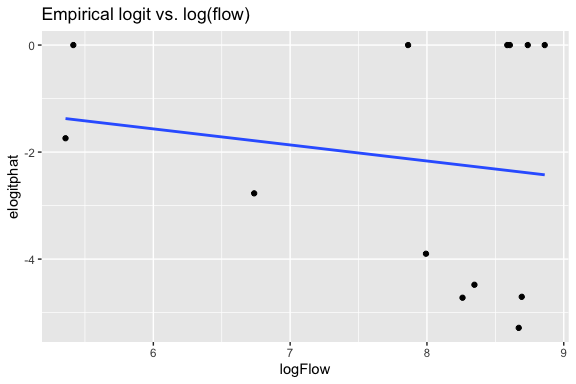